# Лабораторная работа №1

Архитектура компьютера и операционные системы

Кобзев Д. К.

Российский университет дружбы народов, Москва, Россия

# Информация

## Докладчик

- Кобзев Дмитрий Константинович
- студент
- прикладная информатика
- Российский университет дружбы народов
- 1132231936@rudn.ru

# Вводная часть

## Домашнее задание

Получите следующую информацию. Версия ядра Linux (Linux version). Частота процессора (Detected Mhz processor). Модель процессора (CPU0). Объём доступной оперативной памяти (Memory available). Тип обнаруженного гипервизора (Hypervisor detected). Тип файловой системы корневого раздела. Последовательность монтирования файловых систем.

# Выполнение лабораторной работы

## Установка системы на диск

Устанавливаем систему на диск

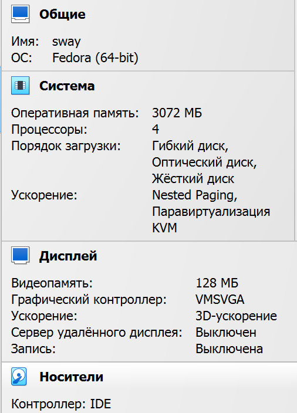

## Установка операционной системы

Устанавливаем операционную систему

[figure not shown]

## Роль супер-пользователя

Переключаемся на роль супер-пользователя

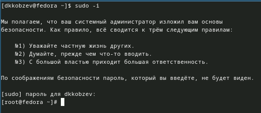

## Обновление всех пакетов`

Обновляем все пакеты

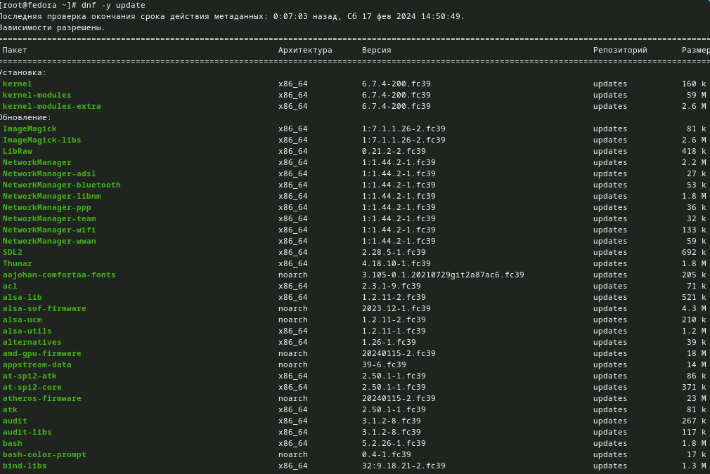

## Установка программы для удобства работы в консоли

Устанавливаем программы для удобства работы в консоли

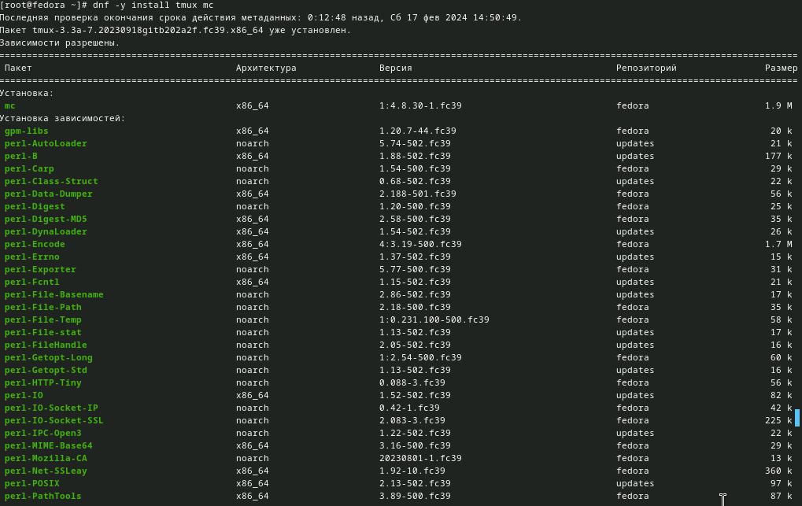

## Установка программного обеспечения для автоматического обновления

Устанавливаем программное обеспечение для автоматического обновления

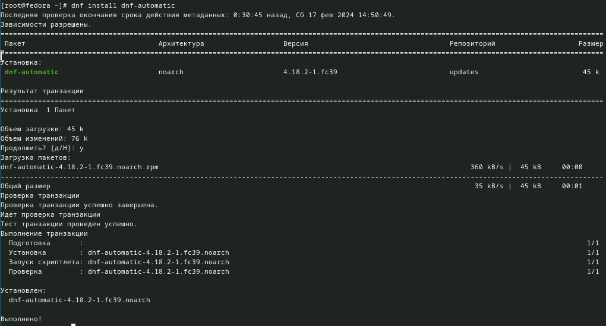

## Запуск таймера

Запускаем таймер

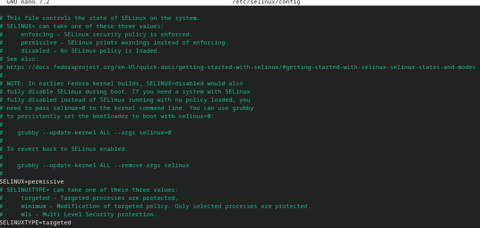

## Роль супер-пользователя

Запускаем терминальный мультиплескор tmux и переключаемся на роль супер-пользователя

## Установка средств разработки

Устанавливаем средства разработки

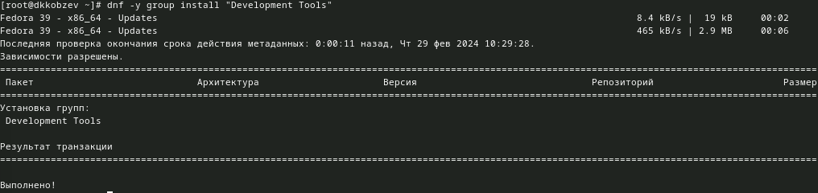

## Установка пакета DKMS

Устанавливаем пакет DKMS

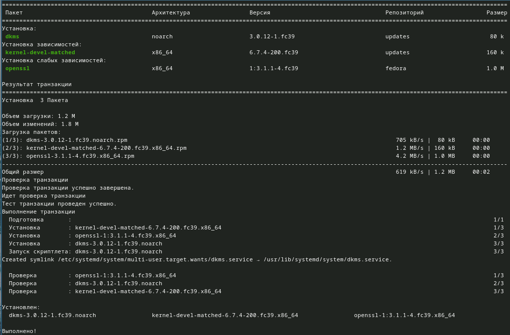

## Подключение образа диска дополнений гостевой ОС

В меню виртуальной машины подключаем образ диска дополнений гостевой ОС

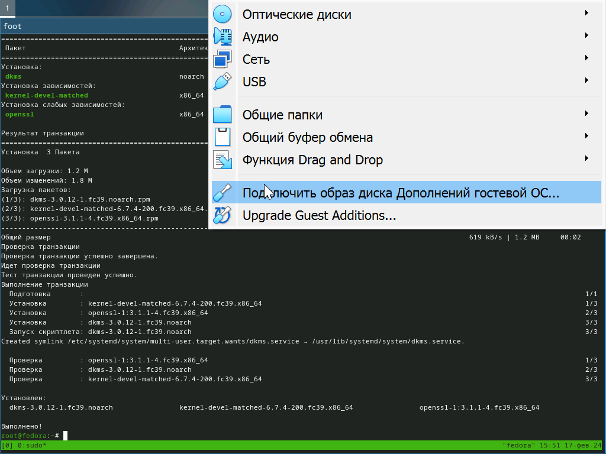

## Подмонтируем диск

Подмонтаж диска

## Устанавливаем драйвера

Установка драйверов

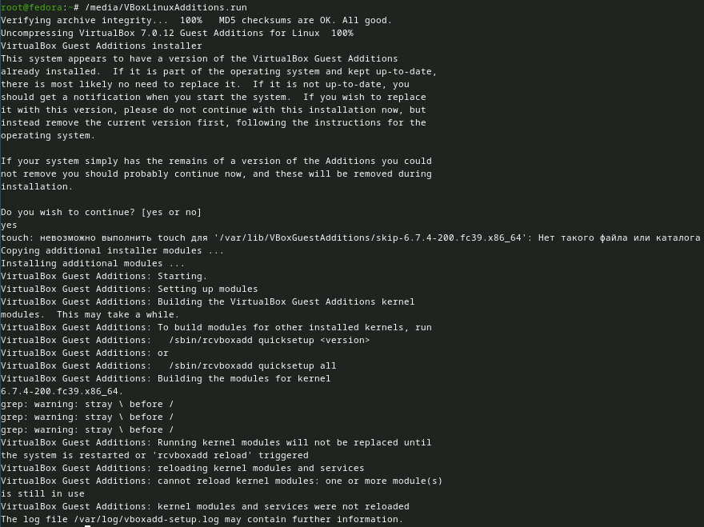

## Создание конфигурационного файла

Создаем конфигурационный файл ~/.config/sway/config.d/95-system-keyboard-config.conf

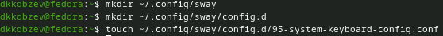

## Редактирование конфигурационного файла

Отредактируем конфигурационный файл ~/.config/sway/config.d/95-system-keyboard-config.conf

## Редактирование конфигурационного файла

Отредактируем конфигурационный файл /etc/X11/xorg.conf.d/00-keyboard.conf

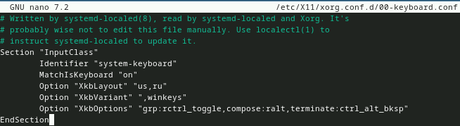

## Создание пользователя

Создаем пользователя, задаем пароль, устанавливаем имя хоста и проверяем, что имя хоста установлено верно

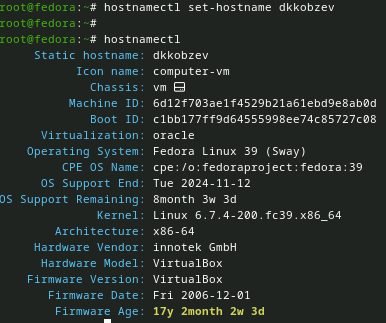

## Добавление своего пользователя в группу vboxsf

Внутри виртуальной машины добавляем своего пользователя в группу vboxsf